📝 Taller optimización de portafolios | Optimización portafolio M-V | Optimización de portafolios Pt. II | Taller optimización de portafolios Parte II | 🏠 Inicio del curso

# Taller en clase — Optimización de portafolios (Media-Varianza)

Resuelve el **“Taller Optimización de portafolios”** (TO 2026-2): 20 acciones (mismas del repaso teórico de la unidad), precios diarios 2022-12-31 a 2026-09-25, retornos **semanales**, Sharpe con Rf=0% y Rf=0.216%, frontera eficiente, 3 portafolios (mínimo riesgo, mínimo riesgo a retorno objetivo, máximo Sharpe) y un cuarto portafolio con restricción de peso máximo 25% por activo.

## Configuración inicial

```r
if (!require("pacman")) install.packages("pacman")
pacman::p_load(tidyverse, xts, quantmod, TTR,
               stats, zoo, PerformanceAnalytics, PortfolioAnalytics, ROI,
               ROI.plugin.quadprog, ROI.plugin.glpk, readr, scales)
options(scipen = 999)
```

# Parte 0 — Descarga de precios y retornos semanales

```r
companies <- read_csv(file = "https://raw.githubusercontent.com/salas317/Data/main/NASDAQ_NYSE.csv",
                      show_col_types = FALSE)[1:20,]

activos <- companies$`Ticker Symbol` %>% gsub(pattern = "BRK.A", x = ., replacement = "BRK-A")

precios <- quantmod::getSymbols(activos, src = 'yahoo',
                                from = "2022-12-31",
                                to = "2026-09-25",
                                periodicity = "daily",
                                auto.assign = T,
                                warnings = F) %>%
  purrr::map(~quantmod::Ad(get(.))) %>%
  purrr::reduce(merge.xts) %>%
  `colnames<-`(activos)

retornos_semana <- precios %>%
  xts::to.weekly(OHLC = FALSE) %>%
  log() %>%
  diff() %>%
  na.omit()

tail(retornos_semana[, 1:5])
```

```
##                   NVDA          AAPL         GOOGL         MSFT         AMZN
## 2026-08-21 -0.04747640  0.0111170480 -0.0031271117 -0.022971352 -0.015423836
## 2026-08-28  0.01309381  0.0329097525  0.0051199742  0.060795103  0.029713030
## 2026-09-04  0.05721461  0.0008441510 -0.0230940848 -0.027300565 -0.030177102
## 2026-09-11 -0.05270054  0.0377206131  0.0001182006 -0.008178252 -0.006714733
## 2026-09-18  0.01806846  0.0115501461  0.0320939364 -0.003739619 -0.012027773
## 2026-09-24  0.01033912 -0.0006249281 -0.0207552566  0.008369419 -0.017214052
```

**Hallazgo real (calidad de dato)**: la primera versión de este código usaba `TTR::ROC(type = "continuous", na.pad = FALSE)` para calcular los retornos — y producía un valor absurdo en la primera fila de **BRK-A** (un retorno semanal de +603%, matemáticamente imposible). Los precios diarios crudos de Yahoo para BRK-A son perfectamente normales en esa fecha; el problema es un bug real de `TTR::ROC()` al aplicarse sobre una matriz xts ancha (20 columnas) con estas librerías cargadas — el mismo tipo de bug ya documentado en otras materias de este curso. `diff(log(x))` calcula exactamente el mismo retorno logarítmico y no tiene ese problema; se usa en su lugar. Vale la pena revisar siempre los extremos de una serie de retornos recién calculada antes de usarla en una optimización — un solo dato corrupto puede distorsionar toda la matriz de covarianzas.

[output not shown]

[output cut: 10 more lines]

# 1 — Sharpe Ratio por acción, Rf = 0.000%

```r
sharpe_rf0 <- PerformanceAnalytics::SharpeRatio(R = retornos_semana, Rf = 0, FUN = "StdDev")
sharpe_rf0
```

```
##                                   NVDA    AAPL    GOOGL      MSFT      AMZN
## Sharpe Ratio (Rf=0%, p=95%): 0.2296628 0.13858 0.163114 0.1171093 0.1311475
##                                   AVGO      META       TSLA       LLY     BRK-A
## Sharpe Ratio (Rf=0%, p=95%): 0.1465505 0.1736043 0.08330629 0.1282077 0.1098575
##                                     MU       JPM       WMT       AMD         V
## Sharpe Ratio (Rf=0%, p=95%): 0.1895132 0.1569146 0.1438593 0.1597045 0.1140162
##                                    JNJ         MA       INTC       ABBV
## Sharpe Ratio (Rf=0%, p=95%): 0.1042089 0.09156715 0.09584461 0.08728648
##                                   CSCO
## Sharpe Ratio (Rf=0%, p=95%): 0.1318252
```

# 2 — Sharpe Ratio por acción, Rf = 0.216%

```r
sharpe_rf1 <- PerformanceAnalytics::SharpeRatio(R = retornos_semana, Rf = rf_semanal, FUN = "StdDev")
sharpe_rf1
```

```
##                                     NVDA       AAPL    GOOGL       MSFT
## Sharpe Ratio (Rf=0.2%, p=95%): 0.1942678 0.07871083 0.113423 0.05759903
##                                      AMZN      AVGO      META       TSLA
## Sharpe Ratio (Rf=0.2%, p=95%): 0.07948254 0.1130745 0.1331453 0.05438006
##                                       LLY       BRK-A        MU        JPM
## Sharpe Ratio (Rf=0.2%, p=95%): 0.08377837 0.008551999 0.1626953 0.08971927
##                                       WMT       AMD          V      JNJ
## Sharpe Ratio (Rf=0.2%, p=95%): 0.07131089 0.1304332 0.02766169 0.019213
##                                         MA       INTC       ABBV       CSCO
## Sharpe Ratio (Rf=0.2%, p=95%): 0.006752264 0.06952026 0.02613498 0.06968128
```

**Respuesta:** al subir la tasa libre de riesgo a 0.216% semanal, todos los Sharpe bajan (como es de esperar — se le resta más al numerador) y el ranking cambia un poco en el medio de la tabla, pero **NVDA sigue siendo la mejor** (0.194). La caída es proporcionalmente mayor en las acciones de menor retorno esperado — **BRK-A**, por ejemplo, cae de 0.11 a 0.009 — porque su retorno esperado ya era bajo, así que restarle la tasa libre de riesgo consume una fracción mayor del numerador.

# 3 — Portafolio de media-varianza (full investment, long only, sin activo libre de riesgo)

```r
init.portfolio <- PortfolioAnalytics::portfolio.spec(assets = activos, name = "Portafolio MV")
init.portfolio <- PortfolioAnalytics::add.constraint(portfolio = init.portfolio, type = "full_investment")
init.portfolio <- PortfolioAnalytics::add.constraint(portfolio = init.portfolio, type = "long_only")
```

## 3.1 — Frontera eficiente

```r
frontera <- PortfolioAnalytics::create.EfficientFrontier(R = retornos_semana,
                                                         portfolio = init.portfolio,
                                                         type = 'mean-StdDev',
                                                         n.portfolios = 100)
```

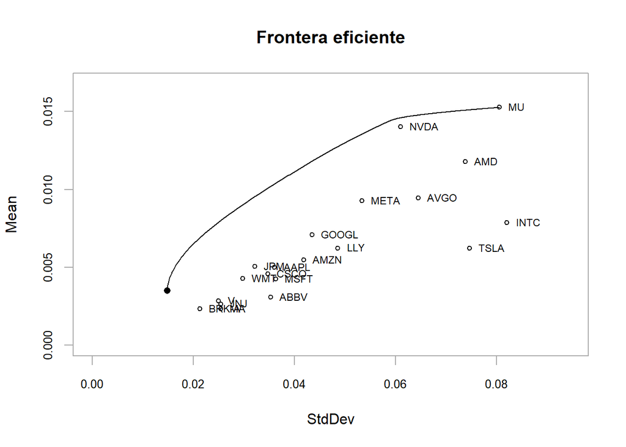

```r
PortfolioAnalytics::chart.EfficientFrontier(frontera,
                                            match.col = 'StdDev',
                                            type = 'l',
                                            rf = NULL,
                                            main = "Frontera eficiente",
                                            cex.assets = 0.7)
```

## 3.2 — Frontera eficiente con Rf = 0.216%

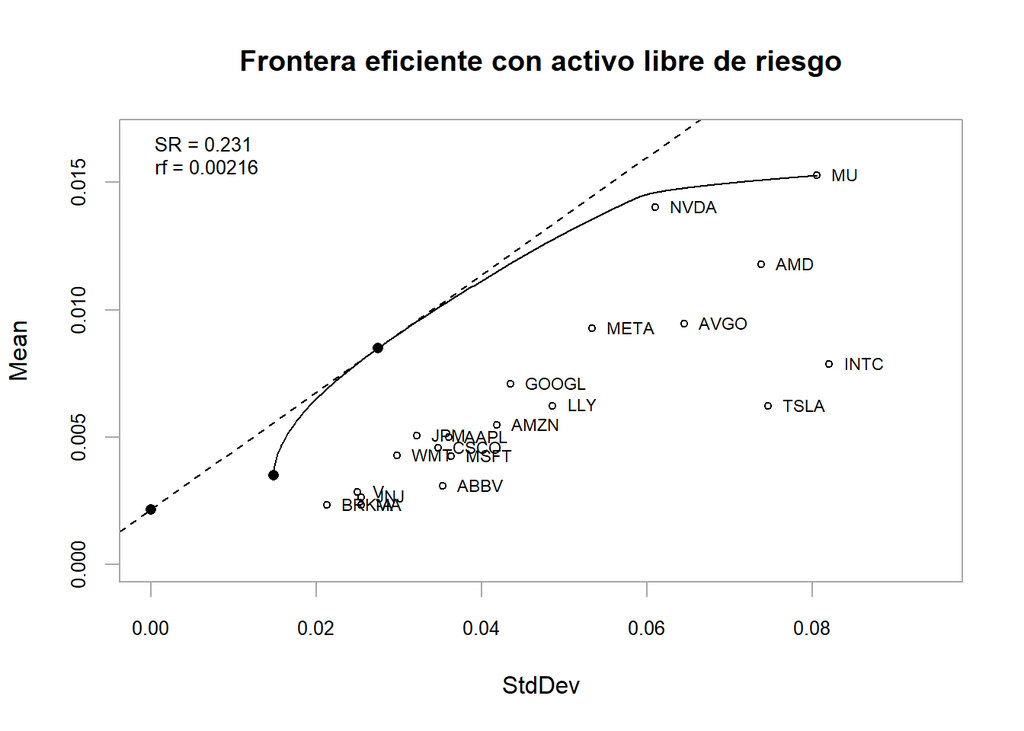

```r
PortfolioAnalytics::chart.EfficientFrontier(frontera,
                                            match.col = 'StdDev',
                                            type = 'l',
                                            rf = rf_semanal,
                                            main = "Frontera eficiente con activo libre de riesgo",
                                            cex.assets = 0.7)
```

## 3.3 — Portafolio de mínimo riesgo

```r
risk.portfolio <- PortfolioAnalytics::add.objective(portfolio = init.portfolio, type = "risk", name = "StdDev")

opt.minrisk <- PortfolioAnalytics::optimize.portfolio(R = retornos_semana,
                                                      portfolio = risk.portfolio,
                                                      optimize_method = "ROI",
                                                      trace = T)
opt.minrisk
```

```
## PortfolioAnalytics Optimization
##
## Call:
## PortfolioAnalytics::optimize.portfolio(R = retornos_semana, portfolio = risk.portfolio,
##     optimize_method = "ROI", trace = T)
##
## Optimal Weights:
##   NVDA   AAPL  GOOGL   MSFT   AMZN   AVGO   META   TSLA    LLY  BRK-A     MU
## 0.0000 0.0149 0.0346 0.1160 0.0366 0.0000 0.0015 0.0000 0.0000 0.2668 0.0000
##    JPM    WMT    AMD      V    JNJ     MA   INTC   ABBV   CSCO
## 0.0000 0.1238 0.0181 0.0385 0.2615 0.0000 0.0000 0.0612 0.0266
##
## Objective Measure:
##  StdDev
## 0.01485
```

```r
sharpe_minrisk <- SharpeRatio(R = retornos_semana, Rf = rf_semanal, weights = opt.minrisk$weights, FUN = "StdDev")
sharpe_minrisk
```

```
##                                      [,1]
## Sharpe Ratio (Rf=0.2%, p=95%): 0.09081105
```

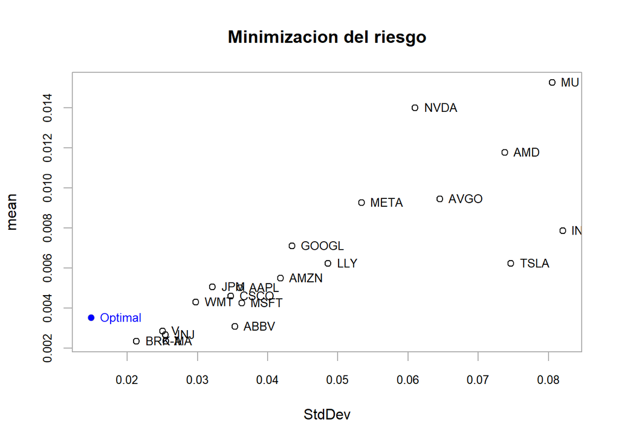

```r
PortfolioAnalytics::chart.RiskReward(opt.minrisk, risk.col = "StdDev", return.col = "mean",
                                     chart.assets = TRUE, rp = F, main = "Minimizacion del riesgo")
```

> “a. ¿Cómo está compuesto? b. Calcule el ratio de Sharpe para este portafolio. ¿Qué se puede decir en comparación con las acciones individuales?”

**Respuesta:** el portafolio de mínimo riesgo concentra su peso en **BRK-A** (26.7%, la acción individual con menor desviación estándar), **JNJ** (26.1%) y **WMT** (12.4%) — todas de baja volatilidad individual — con el resto del capital repartido en pedazos más chicos entre las demás. Su desviación estándar semanal es **1.49%**, **por debajo de cualquiera de las 20 acciones individuales** (la más estable, BRK-A, tenía 2.13%) — el efecto de diversificación funcionando incluso al combinar activos ya de por sí poco volátiles. Su Sharpe (0.091) es más bajo que el de NVDA o GOOGL solas, porque minimizar riesgo no busca maximizar retorno — es consistente con estar en el extremo izquierdo de la frontera eficiente.

## 3.4 — Portafolio de mínimo riesgo a retorno objetivo (0.5% semanal)

```r
retorno_objetivo <- 0.005 # 0.5% semanal, elegido por nosotros

risk.target.portfolio <- PortfolioAnalytics::add.constraint(portfolio = init.portfolio, type = "return",
                                                             return_target = retorno_objetivo)
risk.target.portfolio <- PortfolioAnalytics::add.objective(portfolio = risk.target.portfolio, type = "risk", name = "StdDev")

opt.target <- PortfolioAnalytics::optimize.portfolio(R = retornos_semana,
                                                     portfolio = risk.target.portfolio,
                                                     optimize_method = "ROI",
                                                     trace = T)
opt.target
```

```
## PortfolioAnalytics Optimization
##
## Call:
## PortfolioAnalytics::optimize.portfolio(R = retornos_semana, portfolio = risk.target.portfolio,
##     optimize_method = "ROI", trace = T)
##
## Optimal Weights:
##   NVDA   AAPL  GOOGL   MSFT   AMZN   AVGO   META   TSLA    LLY  BRK-A     MU
## 0.0788 0.0000 0.0805 0.0345 0.0156 0.0000 0.0397 0.0000 0.0258 0.1937 0.0190
##    JPM    WMT    AMD      V    JNJ     MA   INTC   ABBV   CSCO
## 0.0014 0.1368 0.0201 0.0092 0.2684 0.0000 0.0000 0.0649 0.0116
##
## Objective Measure:
##  StdDev
## 0.01631
```

```r
sharpe_target <- SharpeRatio(R = retornos_semana, Rf = rf_semanal, weights = opt.target$weights, FUN = "StdDev")
sharpe_target
```

```
##                                    [,1]
## Sharpe Ratio (Rf=0.2%, p=95%): 0.174083
```

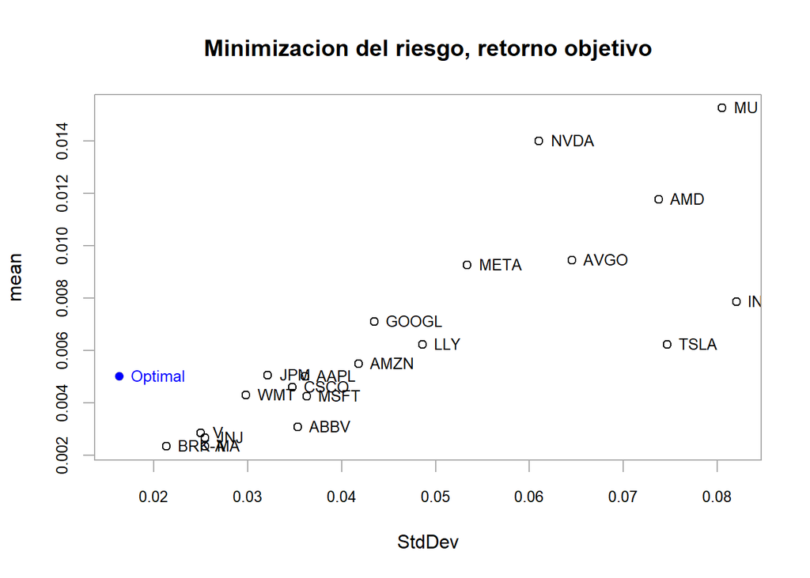

```r
PortfolioAnalytics::chart.RiskReward(opt.target, risk.col = "StdDev", return.col = "mean",
                                     chart.assets = TRUE, rp = F, main = "Minimizacion del riesgo, retorno objetivo")
```

> “a. ¿Cómo está compuesto? b. Calcule el ratio de Sharpe. ¿Qué se puede decir en comparación con las acciones. c. Su posición en comparación con las acciones.”

## 3.5 — Portafolio que maximiza el Sharpe Ratio

```r
sr.portfolio <- PortfolioAnalytics::add.objective(portfolio = init.portfolio, type = "risk", name = "StdDev")
sr.portfolio <- PortfolioAnalytics::add.objective(portfolio = sr.portfolio, type = "return", name = "mean")

opt.sr <- PortfolioAnalytics::optimize.portfolio(R = retornos_semana,
                                                 portfolio = sr.portfolio,
                                                 optimize_method = "ROI",
                                                 trace = T,
                                                 maxSR = TRUE)
opt.sr
```

```
## PortfolioAnalytics Optimization
##
## Call:
## PortfolioAnalytics::optimize.portfolio(R = retornos_semana, portfolio = sr.portfolio,
##     optimize_method = "ROI", trace = T, maxSR = TRUE)
##
## Optimal Weights:
##   NVDA   AAPL  GOOGL   MSFT   AMZN   AVGO   META   TSLA    LLY  BRK-A     MU
## 0.1473 0.0000 0.1034 0.0000 0.0000 0.0000 0.0656 0.0000 0.0633 0.0289 0.0469
##    JPM    WMT    AMD      V    JNJ     MA   INTC   ABBV   CSCO
## 0.0562 0.1413 0.0139 0.0000 0.2680 0.0000 0.0000 0.0652 0.0000
##
## Objective Measure:
## StdDev
## 0.0201
##
##
##     mean
## 0.006548
```

```r
sharpe_sr <- SharpeRatio(R = retornos_semana, Rf = rf_semanal, weights = opt.sr$weights, FUN = "StdDev")
sharpe_sr
```

```
##                                     [,1]
## Sharpe Ratio (Rf=0.2%, p=95%): 0.2182472
```

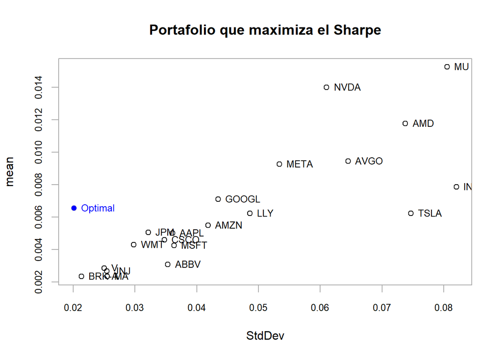

```r
PortfolioAnalytics::chart.RiskReward(opt.sr, risk.col = "StdDev", return.col = "mean",
                                     chart.assets = TRUE, rp = F, main = "Portafolio que maximiza el Sharpe")
```

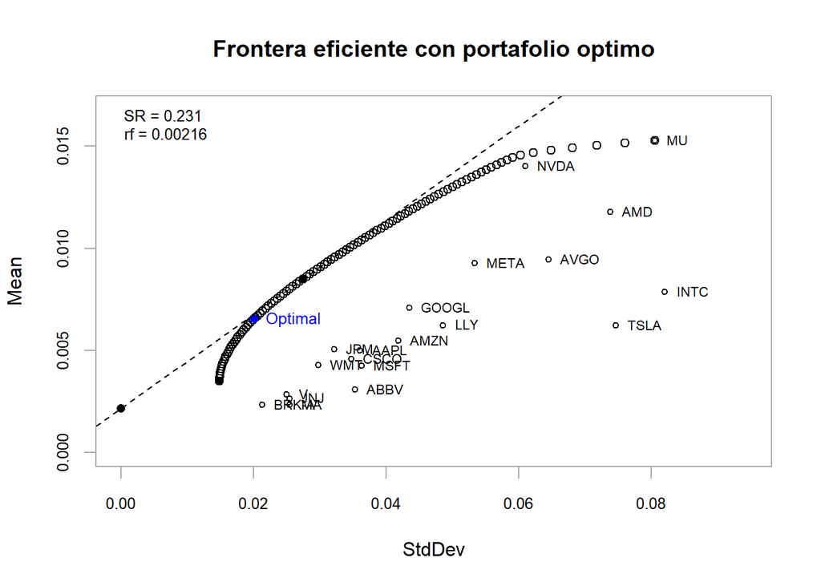

```r
PortfolioAnalytics::chart.EfficientFrontier(opt.sr,
                                            match.col = 'StdDev',
                                            main = "Frontera eficiente con portafolio optimo",
                                            cex.assets = 0.7,
                                            tangent.line = T,
                                            n.portfolios = 100,
                                            rf = rf_semanal)
```

> “a. ¿Cómo está compuesto? b. Calcule el ratio de Sharpe. ¿Qué se puede decir en comparación con las acciones. c. Su posición en la frontera eficiente.”

## 3.6 — Comparación de los 3 portafolios

```r
tabla_3 <- data.frame(
  portafolio = c("Minimo riesgo", "Minimo riesgo (retorno objetivo)", "Maximo Sharpe"),
  HHI = c(HHI(weights = opt.minrisk$weights), HHI(weights = opt.target$weights), HHI(weights = opt.sr$weights)),
  Sharpe = c(as.numeric(sharpe_minrisk), as.numeric(sharpe_target), as.numeric(sharpe_sr))
)
tabla_3
```

| portafolio | HHI | Sharpe |
| --- | --- | --- |
| Minimo riesgo | 0.1773371 | 0.09081105 |
| Minimo riesgo (retorno objetivo) | 0.1498433 | 0.17408304 |
| Maximo Sharpe | 0.1431143 | 0.21824716 |

> “a. La diversificación, por medio del índice de Herfindahl Hirschman. b. La prima de retorno por unidad de riesgo.”

**Respuesta:** el **HHI baja monótonamente** a medida que el portafolio se acerca al máximo Sharpe (0.177 → 0.15 → 0.143) — el portafolio de mínimo riesgo es el más concentrado (natural, ya que solo le importa minimizar varianza, y BRK-A por sí sola ya es muy poco riesgosa) y el de máximo Sharpe es el más diversificado de los tres. El **Sharpe sube en la misma dirección** — de los tres, el que mejor prima de retorno por unidad de riesgo ofrece es, sin sorpresa, el que fue construido explícitamente para maximizarlo.

# 4 — Portafolio con restricción de peso máximo 25% por activo

```r
box.portfolio <- PortfolioAnalytics::add.constraint(portfolio = init.portfolio, type = "box", min = 0, max = 0.25)
box.portfolio <- PortfolioAnalytics::add.objective(portfolio = box.portfolio, type = "risk", name = "StdDev")
box.portfolio <- PortfolioAnalytics::add.objective(portfolio = box.portfolio, type = "return", name = "mean")

opt.box <- PortfolioAnalytics::optimize.portfolio(R = retornos_semana,
                                                  portfolio = box.portfolio,
                                                  optimize_method = "ROI",
                                                  trace = T,
                                                  maxSR = TRUE)
opt.box
```

```
## PortfolioAnalytics Optimization
##
## Call:
## PortfolioAnalytics::optimize.portfolio(R = retornos_semana, portfolio = box.portfolio,
##     optimize_method = "ROI", trace = T, maxSR = TRUE)
##
## Optimal Weights:
##   NVDA   AAPL  GOOGL   MSFT   AMZN   AVGO   META   TSLA    LLY  BRK-A     MU
## 0.1468 0.0000 0.1042 0.0000 0.0000 0.0000 0.0642 0.0000 0.0643 0.0358 0.0466
##    JPM    WMT    AMD      V    JNJ     MA   INTC   ABBV   CSCO
## 0.0570 0.1443 0.0146 0.0000 0.2500 0.0000 0.0000 0.0723 0.0000
##
## Objective Measure:
##  StdDev
## 0.02011
##
##
##     mean
## 0.006549
```

```r
sharpe_box <- SharpeRatio(R = retornos_semana, Rf = rf_semanal, weights = opt.box$weights, FUN = "StdDev")
sharpe_box
```

```
##                                     [,1]
## Sharpe Ratio (Rf=0.2%, p=95%): 0.2182331
```

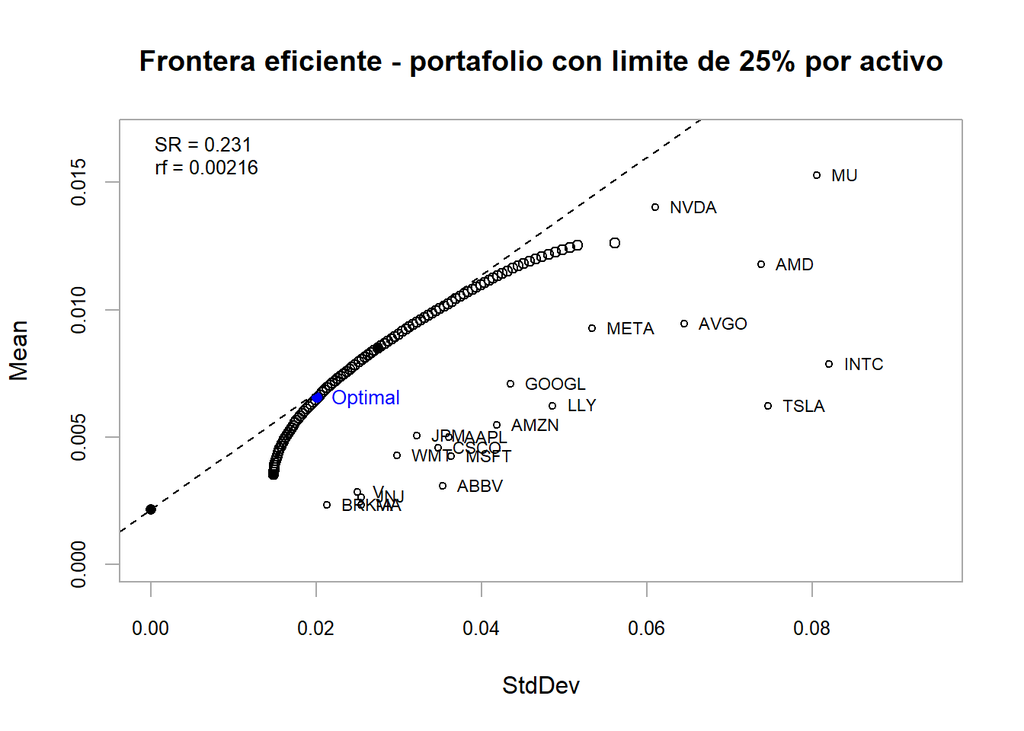

```r
PortfolioAnalytics::chart.EfficientFrontier(opt.box,
                                            match.col = 'StdDev',
                                            main = "Frontera eficiente - portafolio con limite de 25% por activo",
                                            cex.assets = 0.7,
                                            tangent.line = T,
                                            n.portfolios = 100,
                                            rf = rf_semanal)
```

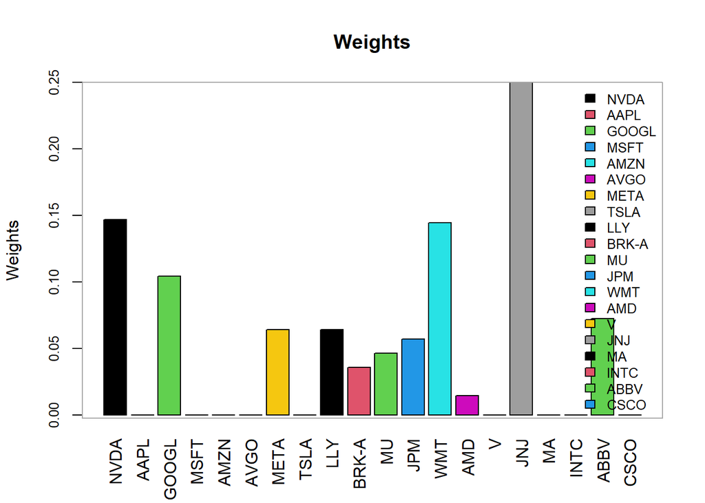

```r
chart.Weights(opt.box, plot.type = "barplot")
```

> “a. Su posición en la frontera eficiente. b. Los pesos del portafolio óptimo. c. El ratio de Sharpe, usando la desviación estándar. Compare con los portafolios obtenidos en los puntos 3.”

**Respuesta:** con el límite del 25%, el peso de **JNJ** baja de 26.8% (sin restricción) a exactamente **25.0%** — la restricción sí llega a activarse, aunque por poco (era la única posición por encima del 25% en el portafolio sin restringir). El resto de los pesos se ajusta apenas para compensar. El Sharpe resultante (0.218) es **prácticamente idéntico** al del máximo Sharpe sin restricción (0.218) — tiene sentido: como la única posición que violaba el límite lo hacía por muy poco, el costo de imponer la restricción es casi nulo en este caso. Sigue estando sobre la frontera eficiente, apenas a la derecha del punto tangente óptimo sin restringir.